# Genomic Variants ~ Session 2

Rockefeller University, Bioinformatics Resource Centre

http://rockefelleruniversity.github.io/RU_GenomicVariants/

# Genomic Variants (part 2)

## About this session

In this session, we are focus on **variant annotation**. You will learn how to annotate variants with rsID of dbSNP and consequences of amino acid changes using the Bioconductor package [VariantAnnotation](https://bioconductor.org/packages/release/bioc/html/VariantAnnotation.html). The VCF file is the same as session 1. You can find it in this file path “data/SAMN01882168_filt.vcf.gz”.

*NOTE: The annotation process is highly memory intensive. We will just focus on the variants in Chromosome 1.*

Required resources - dbSNP: [SNPlocs.Hsapiens.dbSNP144.GRCh37](https://bioconductor.org/packages/release/data/annotation/html/SNPlocs.Hsapiens.dbSNP144.GRCh37.html) - Annotation database: [TxDb.Hsapiens.UCSC.hg19.knownGene](https://bioconductor.org/packages/release/data/annotation/html/TxDb.Hsapiens.UCSC.hg19.knownGene.html)

```r
library(BSgenome.Hsapiens.UCSC.hg19)
library(TxDb.Hsapiens.UCSC.hg19.knownGene)
library(SNPlocs.Hsapiens.dbSNP144.GRCh37)
```

## Outline of this session

- Subset variants in chromosome 1
- Annotate rsID from dbSNP
- Predict amino acid changes
- Integrate information into single table

## Subsetting Variants in chromosome 1

Unlike other Bioconductor objects the VCF object is not easily subset by chromosome. We can use grepl to get a logical vector of all the vcf names that contain the pattern “chr1:”. This logical vecotr can then subset our VCF.

```r
names(vcf)[1:2]
```

```
## [1] "chr1:815337_G/T" "chr1:815341_G/A"
```

```r
grepl(names(vcf),pattern = "chr1:")[1:2]
```

```
## [1] TRUE TRUE
```

```r
vcf_chr1 <- vcf[grepl(names(vcf),pattern = "chr1:")]
rd_chr1 <- rowRanges(vcf_chr1)
```

# Annotating Variants

## Annotate rsID from dbSNP

- Retrieve dbSNP
- Extract SNPs by Chromosome *memory intensive*
- Merge SNPs and variant information by positions

## Retrive dbSNP data

```r
all_snps <- SNPlocs.Hsapiens.dbSNP144.GRCh37
all_snps
```

```
## # SNPlocs object for Homo sapiens (dbSNP Human BUILD 144)
## # reference genome: GRCh37.p13
## # nb of SNPs: 135276726
```

## Retrieve SNPs by chromosome

- Extract chromosome name from the VRange object: *seqnames()@values*
- Retrive SNPs by chromosome: *snpsBySeqname()*

```r
tar_chr <- as.vector(seqnames(rd_chr1)@values)
my_snps <- snpsBySeqname(all_snps, c(tar_chr))
```

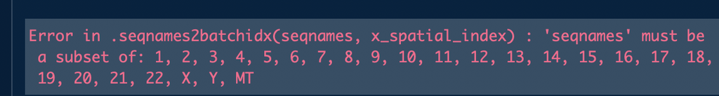

## What’s wrong?

- **seqlevels** in the two objects dosn’t match
- **seqlevelStyle** in the two objects dosn’t match
- **genome** in the tow objects dosen’t match

## check seqlevels

```r
# seqlevels ~ rd
seqlevels(rd_chr1)
```

```
##  [1] "chr1"  "chr2"  "chr3"  "chr4"  "chr5"  "chr6"  "chr7"  "chr8"  "chr9"
## [10] "chr10" "chr11" "chr12" "chr13" "chr14" "chr15" "chr16" "chr17" "chr18"
## [19] "chr19" "chr20" "chr21" "chr22" "chrX"  "chrY"  "chrM"
```

```r
# seqlevels ~ dbSNP
seqlevels(all_snps)
```

```
##  [1] "1"  "2"  "3"  "4"  "5"  "6"  "7"  "8"  "9"  "10" "11" "12" "13" "14" "15"
## [16] "16" "17" "18" "19" "20" "21" "22" "X"  "Y"  "MT"
```

seqname in rd_chr1 is *chr1* but in all_snps is *1*

## check seqlevelStyle

```r
seqlevelsStyle(rd_chr1)
```

```
## [1] "UCSC"
```

```r
seqlevelsStyle(all_snps)
```

```
## [1] "NCBI"    "Ensembl"
```

seqlevelsSytle in rd_chr1 is *UCSC*, but in all_snps is *NCBI Ensembl*

## check genome

```r
genome(rd_chr1)
```

```
##   chr1   chr2   chr3   chr4   chr5   chr6   chr7   chr8   chr9  chr10  chr11
## "hg19" "hg19" "hg19" "hg19" "hg19" "hg19" "hg19" "hg19" "hg19" "hg19" "hg19"
##  chr12  chr13  chr14  chr15  chr16  chr17  chr18  chr19  chr20  chr21  chr22
## "hg19" "hg19" "hg19" "hg19" "hg19" "hg19" "hg19" "hg19" "hg19" "hg19" "hg19"
##   chrX   chrY   chrM
## "hg19" "hg19" "hg19"
```

```r
genome(all_snps)
```

```
##            1            2            3            4            5            6
## "GRCh37.p13" "GRCh37.p13" "GRCh37.p13" "GRCh37.p13" "GRCh37.p13" "GRCh37.p13"
##            7            8            9           10           11           12
## "GRCh37.p13" "GRCh37.p13" "GRCh37.p13" "GRCh37.p13" "GRCh37.p13" "GRCh37.p13"
##           13           14           15           16           17           18
## "GRCh37.p13" "GRCh37.p13" "GRCh37.p13" "GRCh37.p13" "GRCh37.p13" "GRCh37.p13"
##           19           20           21           22            X            Y
## "GRCh37.p13" "GRCh37.p13" "GRCh37.p13" "GRCh37.p13" "GRCh37.p13" "GRCh37.p13"
##           MT
## "GRCh37.p13"
```

genome in rd_chr1 is *hg19*, but in all_snps is *GRCh37.p13*

## Unify seqnames and Process

Lets first grab all SNPs that are on Chr1. Though there are simpler ways to do this, this code will all still work if you are looking at all chromosomes.

```r
tar_chr <- as.vector(seqnames(rd_chr1)@values)
tar_chr <- gsub("chr", "", tar_chr)
tar_chr[grepl(tar_chr, pattern = "M")] <- "MT"
my_snps <- snpsBySeqname(all_snps, c(tar_chr))
my_snps[1:2]
```

```
## UnstitchedGPos object with 2 positions and 2 metadata columns:
##       seqnames       pos strand |   RefSNP_id alleles_as_ambig
##          <Rle> <integer>  <Rle> | <character>      <character>
##   [1]        1     10108      * |  rs62651026                Y
##   [2]        1     10109      * | rs376007522                W
##   -------
##   seqinfo: 25 sequences (1 circular) from GRCh37.p13 genome
```

## Convert seqInfo to UCSC style

We can update the seqlevelsStyle to “UCSC”. This automatically updates all the chromosome names to be UCSC style.We will then just have to update the genome to “hg19”.

```r
# change seqlevelsStyle
seqlevelsStyle(my_snps) <- "UCSC"
# change genome
genome(my_snps) <- "hg19"
```

## Make rsID table

We can extract out information about the SNPs to generate a reference data.frame that contains their position and ID. - posIDX: [chromosome]:[position] ~ the index column for merging data - rsID: rsID from dbSNP

```r
snp_ID <- data.frame(posIDX = paste0(seqnames(my_snps), ":", pos(my_snps)), rsID = my_snps$RefSNP_id,
    stringsAsFactors = FALSE)
head(snp_ID)
```

```
##       posIDX        rsID
## 1 chr1:10108  rs62651026
## 2 chr1:10109 rs376007522
## 3 chr1:10139 rs368469931
## 4 chr1:10150 rs371194064
## 5 chr1:10177 rs201752861
## 6 chr1:10180 rs201694901
```

## Generate Variant table

Next we will reformat our variant information into a data.frame with our fields of interest. To do this we will have to break up the Variant strings.

```r
matV1 <- data.frame(Variant = names(rd_chr1), stringsAsFactors = FALSE)
matV1[1:2, ]
```

```
## [1] "chr1:815337_G/T" "chr1:815341_G/A"
```

- Extract information of variants

```r
matV1$chromosome <- gsub("(.*):(.*)_(.*)/(.*)", "\\1", matV1$Variant)
matV1$start <- gsub("(.*):(.*)_(.*)/(.*)", "\\2", matV1$Variant)
matV1$end <- gsub("(.*):(.*)_(.*)/(.*)", "\\2", matV1$Variant)
matV1$ref_allele <- gsub("(.*):(.*)_(.*)/(.*)", "\\3", matV1$Variant)
matV1$alt_allele <- gsub("(.*):(.*)_(.*)/(.*)", "\\4", matV1$Variant)
matV1$posIDX <- gsub("(.*)_(.*)", "\\1", matV1$Variant)
matV1[1:2, ]
```

```
##           Variant chromosome  start    end ref_allele alt_allele      posIDX
## 1 chr1:815337_G/T       chr1 815337 815337          G          T chr1:815337
## 2 chr1:815341_G/A       chr1 815341 815341          G          A chr1:815341
```

## Annotation table ~ SNP_ID

Now that we have the variant and rsID data.frames we can merge them together to tie together our observed variants with their reference IDs. We can drop the posIDX after this as we do not need it.

```r
matS <- merge(matV1,snp_ID,all.x=TRUE,by="posIDX")
matS <- dplyr::select(matS,-posIDX)
matS[1:2,]
```

```
##              Variant chromosome     start       end ref_allele alt_allele
## 1 chr1:100309252_T/C       chr1 100309252 100309252          T          C
## 2 chr1:100523688_G/A       chr1 100523688 100523688          G          A
##       rsID
## 1 rs520644
## 2     <NA>
```

*dplyr::select* is used to select or remove specific columns in a data frame.

## How many variations in dbSNP

```r
taC2 <- table(!is.na(matS$rsID))
taC2_dat <- as.data.frame(taC2)
taC2
```

```
##
## FALSE  TRUE
##   730  4627
```

## Variations in dbSNP ~ Plotting

```r
ggplot(taC2_dat,aes(x=Var1,y=Freq,fill=Var1))+
  geom_bar(stat='Identity')+
  labs(x="",y="Counts",fill="in_dbSNP")+
  theme(legend.position = "none")
```

## Variations in dbSNP ~ Plotting

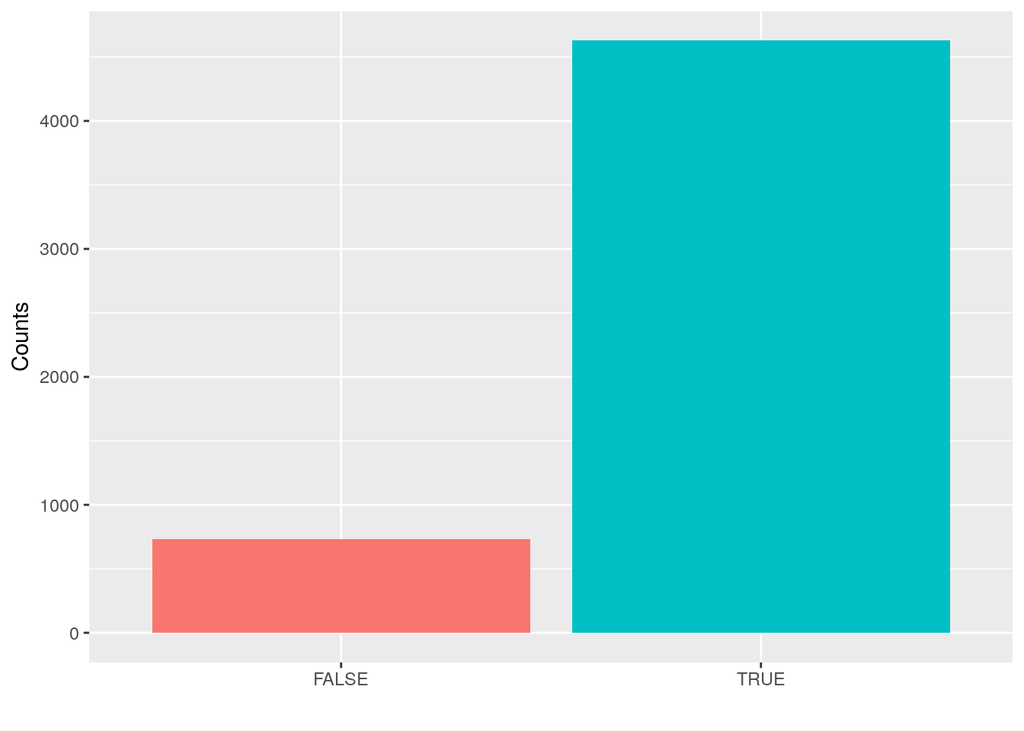

# Variants and Amino Acid Changes

## Predict amino acid changes

- load annotation database: TxDb
- predict amino acid changes: *predictCoding*

## Load TxDb

```r
txdb <- TxDb.Hsapiens.UCSC.hg19.knownGene
```

## TxDb

```r
txdb
```

```
## TxDb object:
## # Db type: TxDb
## # Supporting package: GenomicFeatures
## # Data source: UCSC
## # Genome: hg19
## # Organism: Homo sapiens
## # Taxonomy ID: 9606
## # UCSC Table: knownGene
## # Resource URL: http://genome.ucsc.edu/
## # Type of Gene ID: Entrez Gene ID
## # Full dataset: yes
## # miRBase build ID: GRCh37
## # transcript_nrow: 82960
## # exon_nrow: 289969
## # cds_nrow: 237533
## # Db created by: GenomicFeatures package from Bioconductor
## # Creation time: 2015-10-07 18:11:28 +0000 (Wed, 07 Oct 2015)
## # GenomicFeatures version at creation time: 1.21.30
## # RSQLite version at creation time: 1.0.0
## # DBSCHEMAVERSION: 1.1
```

## Predict amino acid changes

We can run the **predictcoding()** function by providing our VCF object. It will use the Ranges contained within it, to look within a TxDb object.

```r
coding <- predictCoding(vcf_chr1, txdb, seqSource = Hsapiens)
```

## Variants and predicted consequence

```r
coding[1]
```

```
## GRanges object with 1 range and 17 metadata columns:
##                     seqnames    ranges strand | paramRangeID            REF
##                        <Rle> <IRanges>  <Rle> |     <factor> <DNAStringSet>
##   chr1:12907379_T/C     chr1  12907379      - |           NA              T
##                                    ALT      QUAL      FILTER      varAllele
##                     <DNAStringSetList> <numeric> <character> <DNAStringSet>
##   chr1:12907379_T/C                  C     76.77           .              G
##                        CDSLOC    PROTEINLOC   QUERYID        TXID         CDSID
##                     <IRanges> <IntegerList> <integer> <character> <IntegerList>
##   chr1:12907379_T/C       764           255       544        4428         13139
##                          GENEID   CONSEQUENCE       REFCODON       VARCODON
##                     <character>      <factor> <DNAStringSet> <DNAStringSet>
##   chr1:12907379_T/C      649330 nonsynonymous            GAT            GGT
##                             REFAA         VARAA
##                     <AAStringSet> <AAStringSet>
##   chr1:12907379_T/C             D             G
##   -------
##   seqinfo: 25 sequences from hg19 genome
```

## Transform into data.frame

```r
matA <- data.frame(Variant=names(coding),
                   chromosome=seqnames(coding),
                   start=start(coding),end=end(coding),
                   ref_allele=as.character(coding$REF),
                   alt_allele=unlist(lapply(lapply(
                     coding$ALT,`[[`,1),as.character)),
                   GeneID=coding$GENEID,
                   TxID=coding$TXID,
                   Protein_posi=unlist(lapply(lapply(
                     coding$PROTEINLOC,`[[`,1),as.integer)),
                   ref_AA=as.character(coding$REFAA),
                   alt_AA=as.character(coding$VARAA),
                   Type=coding$CONSEQUENCE)
matA$aaChange <- paste0("p.",matA$ref_AA,matA$Protein_posi,matA$alt_AA)
matA <- dplyr::select(matA,-Protein_posi,-ref_AA,-alt_AA)
```

## Annotation table ~ Amino Acid Changes

```r
matA[1:2, ]
```

```
##             Variant chromosome    start      end ref_allele alt_allele GeneID
## 1 chr1:12907379_T/C       chr1 12907379 12907379          T          C 649330
## 2 chr1:12907379_T/C       chr1 12907379 12907379          T          C 343069
##   TxID          Type aaChange
## 1 4428 nonsynonymous  p.D255G
## 2 4429 nonsynonymous  p.D255G
```

## How many variations in coding region

```r
var_in_coding <- data.frame(varName = names(vcf_chr1), in_coding = names(vcf_chr1) %in%
    matA$Variant, stringsAsFactors = FALSE)
table(var_in_coding$in_coding)
```

```
##
## FALSE  TRUE
##  5097    30
```

## How many types of mutations in coding region

```r
taC <- table(matA$Type)
taC_dat <- as.data.frame(taC)
taC
```

```
##
##      nonsense nonsynonymous    synonymous
##             1            49            20
```

- nonsense: mutations causing the appearance of stop codon
- nonsynonymous: mutations causing amino acid changes
- synonymous: mutations not causing amino acid changes

## Mutation types in coding region

```r
ggplot(taC_dat,aes(x=Var1,y=Freq,fill=Var1))+
  geom_bar(stat='Identity')+
  labs(x="",y="Counts",fill="")+
  theme(legend.position = "none")
```

## Mutation types in coding region

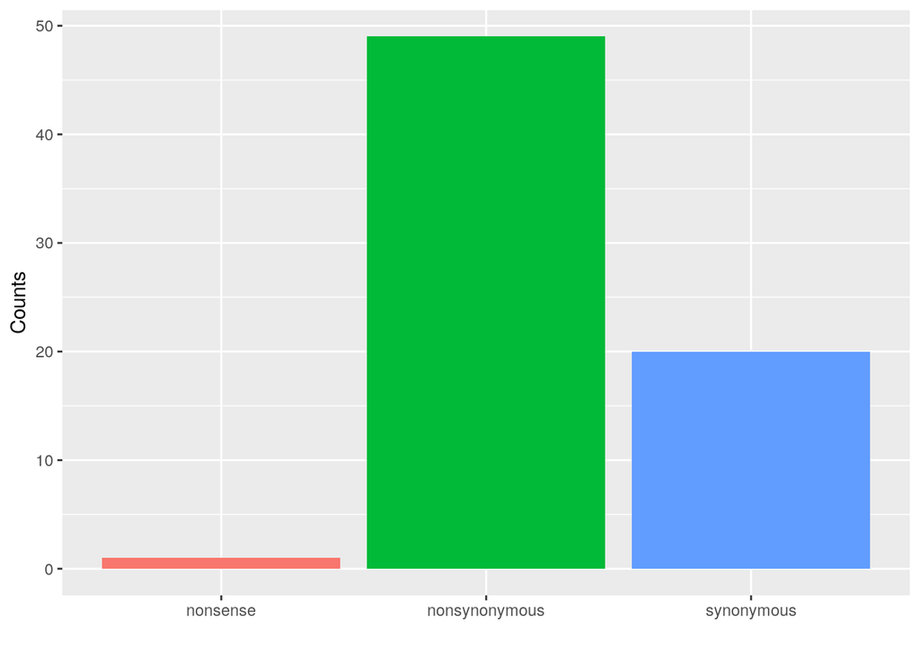

## Integrate SNP and amino acid change into single table

```r
matS$GeneID <- matA$GeneID[match(matS$Variant, matA$Variant)]
matS$AAChange <- matA$GeneID[match(matS$Variant, matA$Variant)]
matS[1:2, ]
```

```
##              Variant chromosome     start       end ref_allele alt_allele
## 1 chr1:100309252_T/C       chr1 100309252 100309252          T          C
## 2 chr1:100523688_G/A       chr1 100523688 100523688          G          A
##       rsID GeneID AAChange
## 1 rs520644   <NA>     <NA>
## 2     <NA>   <NA>     <NA>
```

## Other annotation softwares

- [ANNOVAR](https://doc-openbio.readthedocs.io/projects/annovar/en/latest/)
  - Wang et al, NAR, 2010(38):e164 [link](https://academic.oup.com/nar/article/38/16/e164/1749458)
  - Detailed databases available for human genome
  - Perl-based
- [SnpEff](http://snpeff.sourceforge.net/)
  - Cingolani et al, Landes Biosciense, 2012(6):1 [link](http://snpeff.sourceforge.net/SnpEff_paper.pdf)
  - Support over 38,000 genomes
  - Java-based

## Exercise Time

- Exercise
- Answer